# GLMM Analysis Report

## Methods

Model was fitted using **afex::mixed**.

Family: **gaussian**

Formula: **RT ~ PrevType + Correct + Trial + Frequency + Length + PrevType*meanWeight + NativeLanguage* Length + (1|Subject) + (1|Word)**

## Model Fitting Diagnostics

This section reports diagnostics captured automatically at fit time and should be reviewed before interpreting the results below. A singular fit, a non-convergence message, or fitting warnings do not necessarily invalidate a model, but they do mean its estimates (particularly variance components) should be interpreted with caution.

| Check | Result |
| --- | --- |
| Singular fit | NO |
| Convergence | OK |

### Warnings raised during model fitting

*No warnings were raised while fitting this model.*

## Results

### Model Summary

Full summary output of the fitted model, as printed by R.

```
## Linear mixed model fit by REML. t-tests use Satterthwaite's method ['lmerModLmerTest']
## Formula: RT ~ PrevType + Correct + Trial + Frequency + Length + PrevType *
##     meanWeight + NativeLanguage * Length + (1 | Subject) + (1 |      Word)
##    Data: data
##
## REML criterion at convergence: -965.9
##
## Scaled residuals:
##     Min      1Q  Median      3Q     Max
## -2.3131 -0.6401 -0.1124  0.4653  6.0953
##
## Random effects:
##  Groups   Name        Variance Std.Dev.
##  Word     (Intercept) 0.002254 0.04748
##  Subject  (Intercept) 0.018352 0.13547
##  Residual             0.028330 0.16831
## Number of obs: 1659, groups:  Word, 79; Subject, 21
##
## Fixed effects:
##                          Estimate Std. Error         df t value Pr(>|t|)
## (Intercept)             6.477e+00  5.560e-02  9.593e+01 116.506  < 2e-16 ***
## PrevType1               4.620e-03  1.120e-02  1.605e+03   0.413 0.680018
## Correct1                3.238e-02  1.133e-02  1.628e+03   2.857 0.004333 **
## Trial                  -2.450e-04  8.900e-05  1.592e+03  -2.753 0.005970 **
## Frequency              -4.802e-02  6.387e-03  7.506e+01  -7.519 9.73e-11 ***
## Length                  1.194e-02  4.050e-03  7.480e+01   2.949 0.004254 **
## meanWeight              2.804e-02  7.275e-03  7.437e+01   3.854 0.000245 ***
## NativeLanguage1        -2.749e-02  3.297e-02  2.712e+01  -0.834 0.411688
## PrevType1:meanWeight    1.009e-02  4.058e-03  1.601e+03   2.488 0.012959 *
## Length:NativeLanguage1 -8.509e-03  2.254e-03  1.554e+03  -3.774 0.000167 ***
## ---
## Signif. codes:  0 '***' 0.001 '**' 0.01 '*' 0.05 '.' 0.1 ' ' 1
##
## Correlation of Fixed Effects:
##             (Intr) PrvTy1 Crrct1 Trial  Frqncy Length mnWght NtvLn1 PrT1:W
## PrevType1   -0.010
## Correct1    -0.159 -0.023
## Trial       -0.166  0.000 -0.004
## Frequency   -0.555  0.001 -0.092 -0.006
## Length      -0.653  0.011  0.010 -0.006  0.365
## meanWeight  -0.164  0.024  0.055  0.015 -0.389  0.069
## NativeLngg1 -0.086 -0.008  0.019 -0.011 -0.002  0.032  0.001
## PrvTyp1:mnW  0.009 -0.927  0.020  0.000 -0.002 -0.008 -0.025  0.009
## Lngth:NtvL1  0.040  0.016 -0.066  0.024  0.006 -0.080 -0.003 -0.404 -0.016
```

### Random Effects

Both the **variance** (σ²) and the **standard deviation** (σ) of each random-effect term are shown. The residual row is the within-group (observation-level) variance.

Random-effects variance components

| Group | Effect | Variance | Std.Dev. |
| --- | --- | --- | --- |
| Word | (Intercept) | 0.002254 | 0.04748 |
| Subject | (Intercept) | 0.018350 | 0.13550 |
| Residual | (Residual) | 0.028330 | 0.16830 |

### Fixed Effects

Fixed Effects

Estimate

Std. Error

df

t value

Pr(>|t|)

(Intercept)

6.477

0.056

96

116.506

< 1e-04

***

PrevType1

0.005

0.011

1605

0.413

0.680018

Correct1

0.032

0.011

1628

2.857

0.004333

Trial

0.000

0.000

1592

-2.753

0.005970

Frequency

-0.048

0.006

75

-7.519

< 1e-04

***

Length

0.012

0.004

75

2.949

0.004254

meanWeight

0.028

0.007

74

3.854

0.000245

***

NativeLanguage1

-0.027

0.033

27

-0.834

0.411688

PrevType1:meanWeight

0.010

0.004

1601

2.488

0.012959

Length:NativeLanguage1

-0.009

0.002

1554

-3.774

0.000167

***

### ANOVA (Type III)

```
## Mixed Model Anova Table (Type 3 tests, KR-method)
##
## Model: RT ~ PrevType + Correct + Trial + Frequency + Length + PrevType *
## Model:     meanWeight + NativeLanguage * Length + (1 | Subject) + (1 |
## Model:     Word)
## Data: df
##                       num Df   den Df       F    Pr(>F)
## PrevType                   1 1605.394  0.1700 0.6801879
## Correct                    1 1627.730  8.1452 0.0043722 **
## Trial                      1 1592.430  7.5738 0.0059893 **
## Frequency                  1   76.082 56.5349 9.076e-11 ***
## Length                     1   75.826  8.6959 0.0042384 **
## meanWeight                 1   75.392 14.8545 0.0002423 ***
## NativeLanguage             1   27.113  0.6952 0.4116886
## PrevType:meanWeight        1 1601.185  6.1823 0.0130047 *
## Length:NativeLanguage      1 1555.486 14.2445 0.0001666 ***
## ---
## Signif. codes:  0 '***' 0.001 '**' 0.01 '*' 0.05 '.' 0.1 ' ' 1
```

### Model Performance

Variance explained and clustering (R2, ICC)

| Metric | Value |
| --- | --- |
| R2 marginal (fixed effects only) | 0.1886 |
| R2 conditional (fixed + random effects) | 0.5303 |
| ICC (adjusted) | 0.4211 |
| ICC (unadjusted) | 0.3417 |

Information criteria and error measures

| Metric | Value |
| --- | --- |
| AIC | -939.9000 |
| AICc | -939.7000 |
| BIC | -869.5000 |
| RMSE | 0.1644 |
| Sigma | 0.1683 |

**How to read these measures**

- **R2 marginal**: proportion of variance explained by the fixed effects alone.
- **R2 conditional**: proportion of variance explained by the fixed and random effects together.
- **ICC**: proportion of the total (non-fixed-effect) variance attributable to differences between groups/subjects; higher values mean observations within the same group are more alike.
- This model was fitted by REML: AIC/BIC are only comparable between models with identical fixed effects. Refit by ML to compare models with different fixed effects.

### DHARMa Residual Diagnostics

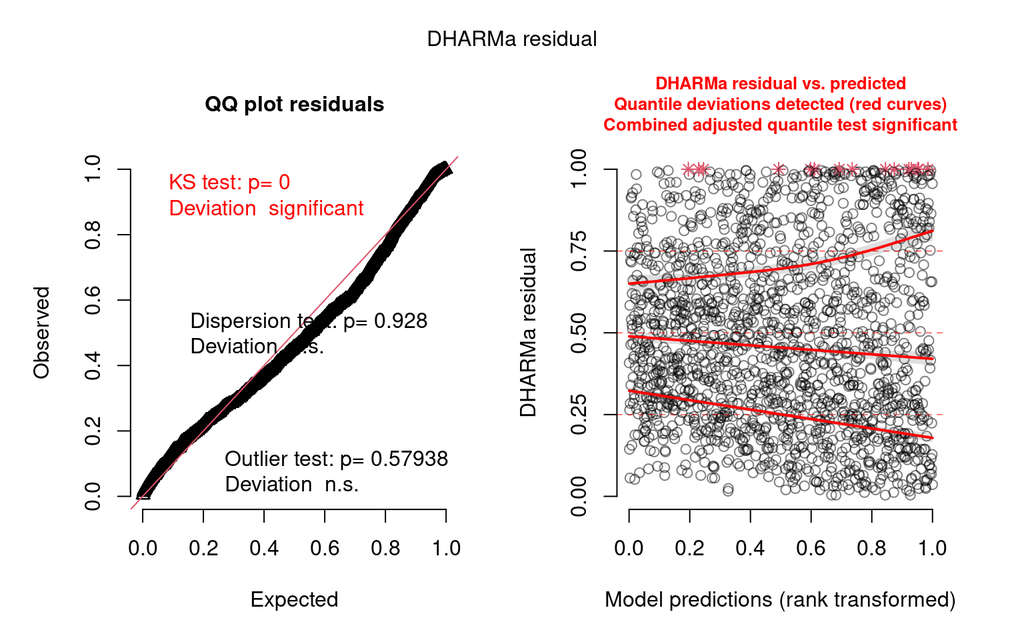